# Final Project Long EDA Report

Junhua Tan

03/15/2020

# Introduction

This data was published by UC Irvine Machine Learning Repository in 1988 for the purpose of training a model in which predict the presence of heart disease in the patient(data source: Janosi A., Steinbrunn W., M.D. (2019). UCI Machine Learning Repository [https://archive.ics.uci.edu/ml/datasets/Heart+Disease]. Irvine, CA: University of California, School of Information and Computer Science.). With this information, the researchers hope to help doctors to quickly make quicker, better judgement and provide care needed for patients. The data folder contains 1 csv file with 303 instances of 75 attributes. However, for our purpose of this final project, I will use only a subset of 14 attributes like all published experiments with this dataset did. In the future I might also consider incorporating additional attributes to provide a better summary of the disease.

## Set-up

1. Load libraries

```r
# Loading package(s)
library(MASS)
library(tidyverse)
library(GGally)
library(janitor)
library(skimr)
library(corrplot)
library(modelr)
library(broom)
library(glmnet)
library(leaps)
```

2. Set Seed

```r
RNGversion("3.5")
set.seed(27183)
```

3. Read processed dataset

```r
# Read processed dataset
train <- read_csv(
  "data/processed/heart_train.csv",
  col_types = cols(
    age = col_double(),
    sex = col_factor(),
    cp = col_factor(),
    trestbps = col_double(),
    chol = col_double(),
    fbs = col_factor(),
    restecg = col_factor(),
    thalach = col_double(),
    exang = col_factor(),
    oldpeak = col_double(),
    slope = col_factor(),
    ca = col_factor(),
    thal = col_factor(),
    target = col_factor()
  )) %>%
  clean_names()

test <- read_csv(
  "data/processed/heart_test.csv",
  col_types = cols(
    age = col_double(),
    sex = col_factor(),
    cp = col_factor(),
    trestbps = col_double(),
    chol = col_double(),
    fbs = col_factor(),
    restecg = col_factor(),
    thalach = col_double(),
    exang = col_factor(),
    oldpeak = col_double(),
    slope = col_factor(),
    ca = col_factor(),
    thal = col_factor(),
    target = col_factor()
  )) %>%
  clean_names()
```

4. View proportion of response variable in training data.

```r
train %>%
  skim_without_charts()
```

Data summary

| Name | Piped data |
| --- | --- |
| Number of rows | 273 |
| Number of columns | 14 |
| _______________________ |  |
| Column type frequency: |  |
| factor | 9 |
| numeric | 5 |
| ________________________ |  |
| Group variables | None |

**Variable type: factor**

| skim_variable | n_missing | complete_rate | ordered | n_unique | top_counts |
| --- | --- | --- | --- | --- | --- |
| sex | 0 | 1 | FALSE | 2 | 1: 184, 0: 89 |
| cp | 0 | 1 | FALSE | 4 | 0: 129, 2: 82, 1: 43, 3: 19 |
| fbs | 0 | 1 | FALSE | 2 | 0: 229, 1: 44 |
| restecg | 0 | 1 | FALSE | 3 | 1: 138, 0: 132, 2: 3 |
| exang | 0 | 1 | FALSE | 2 | 0: 184, 1: 89 |
| slope | 0 | 1 | FALSE | 3 | 2: 131, 1: 122, 0: 20 |
| ca | 0 | 1 | FALSE | 5 | 0: 158, 1: 59, 2: 33, 3: 19 |
| thal | 0 | 1 | FALSE | 4 | 2: 149, 3: 105, 1: 17, 0: 2 |
| target | 0 | 1 | FALSE | 2 | 1: 154, 0: 119 |

**Variable type: numeric**

| skim_variable | n_missing | complete_rate | mean | sd | p0 | p25 | p50 | p75 | p100 |
| --- | --- | --- | --- | --- | --- | --- | --- | --- | --- |
| age | 0 | 1 | 54.33 | 9.17 | 29 | 47 | 55.0 | 61.0 | 77.0 |
| trestbps | 0 | 1 | 131.93 | 18.00 | 94 | 120 | 130.0 | 140.0 | 200.0 |
| chol | 0 | 1 | 246.77 | 53.09 | 126 | 211 | 240.0 | 275.0 | 564.0 |
| thalach | 0 | 1 | 149.51 | 22.97 | 71 | 133 | 152.0 | 166.0 | 202.0 |
| oldpeak | 0 | 1 | 1.01 | 1.17 | 0 | 0 | 0.6 | 1.6 | 6.2 |

```r
# Proportions of Patient with Heart Disease
train %>%
  count(target) %>%
  mutate(prop = n/sum(n))
```

| target | n | prop |
| --- | --- | --- |
| 1 | 154 | 0.5641026 |
| 0 | 119 | 0.4358974 |

We have over 50% of data with patients diagnosed with heart diseases, which may implies an potential bias in our dataset.

## Best subset variable selection

### Create train and test tibble

```r
heart_db <- tibble(
  train = train %>% list(),
  test = test %>% list())
```

### Ridge

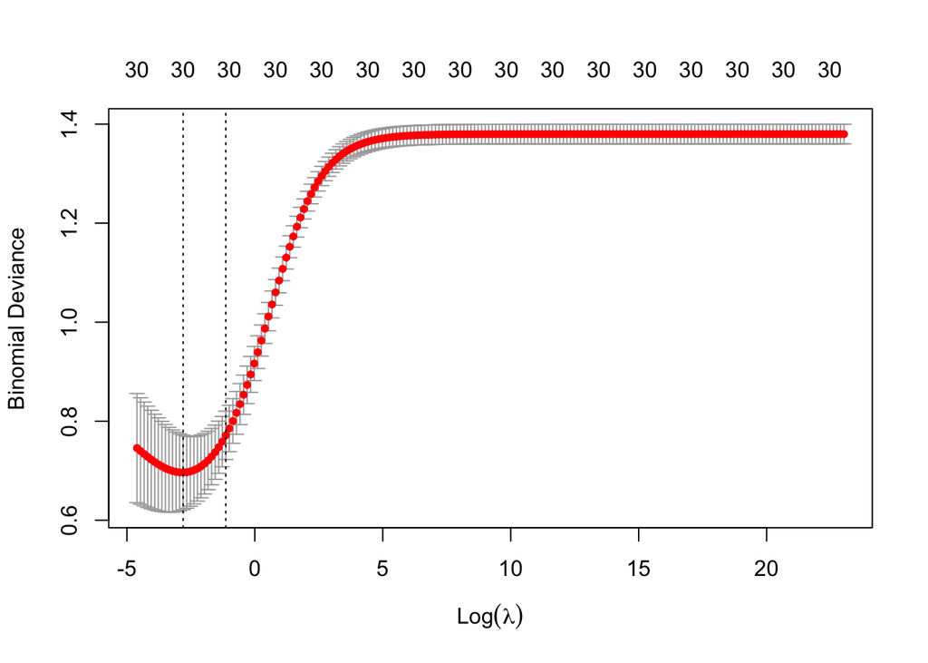

```r
# lambda grid to search -- use for ridge regression (200 values)
lambda_grid <- 10^seq(-2, 10, length = 200)

# ridge regression: 10-fold cv
ridge_cv <- heart_db %>%
  pluck("train", 1) %>%
  glmnetUtils::cv.glmnet(
    formula = target ~ .,
    data = .,
    alpha = 0, # for ridge regression
    nfolds = 10,
    lambda = lambda_grid,
    family = "binomial"
  )

# Check plot of cv error
plot(ridge_cv)
```

```r
# ridge's best lambdas
ridge_lambda_min <- ridge_cv$lambda.min
ridge_lambda_1se <- ridge_cv$lambda.1se
```

### Lasso

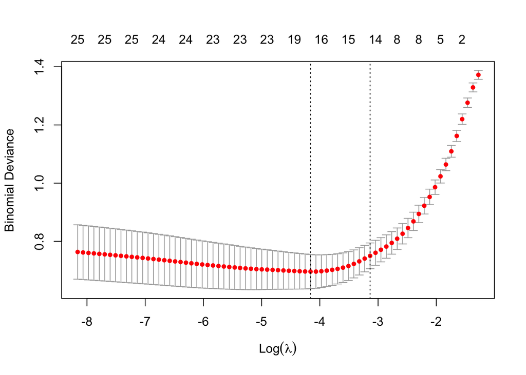

```r
# lasso: 10-fold cv
lasso_cv <- heart_db %>%
  pluck("train", 1) %>%
  glmnetUtils::cv.glmnet(
    formula = target ~ . ,
    data = .,
    alpha = 1,
    nfolds = 10,
    family = "binomial"
  )

plot(lasso_cv)
```

```r
# lasso's best lambdas
lasso_lambda_1se <- lasso_cv$lambda.1se
lasso_lambda_min <- lasso_cv$lambda.min
```

### Comparison

From Ridge and Lasso result, we can see that variables such as the sex of the patient (`sex`), the presence and type of chest pain if any (`cp`), resting electrocardiographic results (`restecg`), exercise induced angina (`exang`), the slope of the peak exercise ST segment (`slope`), ST depression induced by exercise relative to rest (`oldpeak`), number of major vessels (0-4) colored by flourosopy (`ca`) and heart condition (`thal`) are generally picked up as significant by all four models with ridge and lasso lambdas that produce the smallest test error and the lambda within 1 standard error of that best lambda.

```r
x <- model.matrix(target~., train)[,-1]
y <- train$target

heart_glmnet <- tibble(train = heart_db$train,
                        test  = heart_db$test) %>%
  mutate(ridge_min = map(train, ~ glmnet(x, y, data = .x,
                                         alpha = 0, lambda = ridge_lambda_min,
                                         family="binomial")),
         ridge_1se = map(train, ~ glmnet(x, y, data = .x,
                                         alpha = 0, lambda = ridge_lambda_1se,
                                         family="binomial")),
         lasso_min = map(train, ~ glmnet(x, y, data = .x,
                                         alpha = 1, lambda = lasso_lambda_min,
                                         family="binomial")),
         lasso_1se = map(train, ~ glmnet(x, y, data = .x,
                                         alpha = 1, lambda = lasso_lambda_1se,
                                         family="binomial"))) %>%
  pivot_longer(cols = c(-test, -train), names_to = "method", values_to = "fit")

# Inspect/compare model coefficients
heart_glmnet %>%
  pluck("fit") %>%
  map( ~ coef(.x) %>%
         as.matrix() %>%
         as.data.frame() %>%
         rownames_to_column("name")) %>%
  reduce(full_join, by = "name") %>%
  mutate_if(is.double, ~ if_else(. == 0, NA_real_, .)) %>%
  rename(ridge_min = s0.x,
         ridge_1se = s0.y,
         lasso_min = s0.x.x,
         lasso_1se = s0.y.y) %>%
  knitr::kable(digits = 3)
```

| name | ridge_min | ridge_1se | lasso_min | lasso_1se |
| --- | --- | --- | --- | --- |
| (Intercept) | -2.540 | -1.398 | -2.850 | -0.886 |
| age | -0.001 | 0.006 | NA | NA |
| sex0 | -0.840 | -0.417 | -0.888 | -0.446 |
| cp2 | -0.566 | -0.320 | -0.422 | NA |
| cp3 | -0.909 | -0.389 | -0.761 | NA |
| cp0 | 0.805 | 0.514 | 1.118 | 1.127 |
| trestbps | 0.015 | 0.006 | 0.016 | 0.004 |
| chol | 0.002 | 0.001 | NA | NA |
| fbs1 | -0.088 | 0.017 | NA | NA |
| restecg0 | 0.427 | 0.202 | 0.407 | 0.068 |
| restecg2 | 0.465 | 0.220 | NA | NA |
| thalach | -0.013 | -0.008 | -0.013 | -0.011 |
| exang1 | 0.544 | 0.406 | 0.470 | 0.346 |
| oldpeak | 0.322 | 0.185 | 0.395 | 0.272 |
| slope1 | 0.597 | 0.357 | 0.617 | 0.343 |
| slope0 | 0.177 | 0.096 | NA | NA |
| ca1 | 1.068 | 0.431 | 1.364 | 0.654 |
| ca2 | 1.329 | 0.548 | 1.684 | 0.775 |
| ca3 | 1.157 | 0.547 | 1.289 | 0.539 |
| ca4 | 0.106 | -0.038 | NA | NA |
| thal3 | 1.193 | 0.637 | 1.429 | 1.137 |
| thal1 | 0.539 | 0.314 | 0.341 | 0.016 |
| thal0 | 1.116 | 0.325 | 0.455 | NA |

## Model Building

Here, we compare three models with each methods: 1) using all variables in the dataset, 2) using theoretically important variables explored in EDA, 3) using variables from the ridge and lasso best subset selection.

### Generalized Linear Model

Model 2 with theoretically important variables explored in EDA produced the smallest test error of 0.233 using generalized linear model.

```r
# Helper function for calculating error rate
error_rate_glm <- function(data, model){
  data %>%
    mutate(pred_prob = predict(model, newdata = data, type = "response"),
           pred_target = if_else(pred_prob > 0.5, "0", "1"),
           error = pred_target != target) %>%
    pull(error) %>%
    mean()
}

# Helper function for confusion matrix
confusion_mat_glm <- function(data, model){
  data %>%
    mutate(pred_prob = predict(model, newdata = data, type = "response"),
           pred_target = if_else(pred_prob > 0.5, "0", "1")) %>%
    count(target, pred_target) %>%
    mutate(prop = n / sum(n))
}
```

```r
glm_fits <- heart_db %>%
  mutate(mod_01 = map(train, glm,
                      formula = target ~ .,
                      family = binomial),
         mod_02 = map(train, glm,
                      formula = target ~ age + sex + cp + thalach + exang + oldpeak,
                      family = binomial),
         mod_03 = map(train, glm,
                      formula = target ~ sex + cp + restecg + exang + oldpeak + slope + ca + thal,
                      family = binomial)) %>%
  pivot_longer(cols = contains("mod_"), names_to = "model_name", values_to =  "model_fit")

# Calculate model error
glm_fits <- glm_fits %>%
  mutate(train_error = map2_dbl(train, model_fit, error_rate_glm),
         test_error  = map2_dbl(test, model_fit, error_rate_glm),
         test_confusion = map2(test, model_fit, confusion_mat_glm))

glm_fits %>%
  dplyr::select(model_name, train_error, test_error) %>%
  arrange(test_error) %>%
  knitr::kable()
```

| model_name | train_error | test_error |
| --- | --- | --- |
| mod_02 | 0.1758242 | 0.2333333 |
| mod_01 | 0.0915751 | 0.3333333 |
| mod_03 | 0.0952381 | 0.3333333 |

### KNN

Model 3 produced the smallest test error of 0.233 using KNN with folds of 5.

```r
#### Helper Functions

# tidy wrapper function for knn
knn_tidy <- function(train, test, pred_vars, response_var, ...){
  train_reduced <- train %>% dplyr::select(!!pred_vars) %>% as.matrix()
  test_reduced  <- test %>% dplyr::select(!!pred_vars) %>% as.matrix()
  train_class   <- train %>% dplyr::select(!!response_var) %>% as.matrix()

  preds <- class::knn(train = train_reduced,
                      test = test_reduced,
                      cl = train_class, ...)

  pred_name <- paste0("pred_", response_var)
  tibble(!!pred_name := preds)
}

# Function to calculate knn error rate
error_rate_knn <- function(data, pred_value){
  data %>%
    bind_cols(pred_value) %>%
    mutate(error = target != pred_target) %>%
    pull(error) %>%
    mean()
}

# Function to form knn confusion matrix
confusion_mat_knn <- function(data, pred_value){
  data %>%
    bind_cols(pred_value) %>%
    count(target, pred_target) %>%
    mutate(prop = n / sum(n))
}
```

```r
# Set-up tibble with predictor vars
pred_var <- tibble(pred_set = list(c("age", "sex", "cp", "thalach",
                                     "trestbps", "chol", "fbs", "restecg",
                                     "exang", "oldpeak", "slope", "ca", "thal"),
                                   c("age", "sex", "cp", "thalach", "oldpeak",
                                     "exang"),
                                   c("sex", "cp", "restecg", "exang", "oldpeak",
                                     "slope", "ca", "thal")))

# Set-up tibble with num of neighbors (k)
k_values <- tibble(k_value = c(1, 2, 5, 10, 15))

# Set-up tibble with model fitting info & fit to test dataset
knn_fits <- heart_db %>%
  crossing(k_values) %>%
  crossing(pred_var) %>%
  mutate(knn_preds = pmap(list(train, test, pred_set,"target", k_value),
                          knn_tidy))

# update knn_fits with error and confusion info
knn_fits <- knn_fits %>%
  mutate(test_error = map2_dbl(test, knn_preds, error_rate_knn),
         test_confusion = map2(test, knn_preds, confusion_mat_knn))

# Compare models by test_error
knn_fits %>%
  dplyr::select(pred_set, k_value, test_error) %>%
  mutate(pred_set = map_chr(pred_set, ~ str_c(.x, collapse = ", " ))) %>%
  arrange(test_error) %>%
  knitr::kable()
```

| pred_set | k_value | test_error |
| --- | --- | --- |
| sex, cp, restecg, exang, oldpeak, slope, ca, thal | 5 | 0.2333333 |
| sex, cp, restecg, exang, oldpeak, slope, ca, thal | 1 | 0.2666667 |
| age, sex, cp, thalach, oldpeak, exang | 2 | 0.2666667 |
| age, sex, cp, thalach, oldpeak, exang | 1 | 0.3000000 |
| sex, cp, restecg, exang, oldpeak, slope, ca, thal | 10 | 0.3000000 |
| sex, cp, restecg, exang, oldpeak, slope, ca, thal | 15 | 0.3000000 |
| sex, cp, restecg, exang, oldpeak, slope, ca, thal | 2 | 0.3333333 |
| age, sex, cp, thalach, oldpeak, exang | 5 | 0.3333333 |
| age, sex, cp, thalach, oldpeak, exang | 15 | 0.3333333 |
| age, sex, cp, thalach, oldpeak, exang | 10 | 0.3666667 |
| age, sex, cp, thalach, trestbps, chol, fbs, restecg, exang, oldpeak, slope, ca, thal | 10 | 0.4666667 |
| age, sex, cp, thalach, trestbps, chol, fbs, restecg, exang, oldpeak, slope, ca, thal | 1 | 0.5000000 |
| age, sex, cp, thalach, trestbps, chol, fbs, restecg, exang, oldpeak, slope, ca, thal | 5 | 0.5000000 |
| age, sex, cp, thalach, trestbps, chol, fbs, restecg, exang, oldpeak, slope, ca, thal | 2 | 0.5666667 |
| age, sex, cp, thalach, trestbps, chol, fbs, restecg, exang, oldpeak, slope, ca, thal | 15 | 0.5666667 |

### LDA Model

Model 2 with theoretically important variables explored in EDA produced the smallest test error of 0.233 using LDA. The confusion matrix shows that the model is generally good at predicting patients with heart disease with (10/11 cases) but tends to over-estimate the patients who do not have heart disease as they do (6/19).

```r
# Helper function for calculating lda error rate
error_rate_lda <- function(data, model){
  data %>%
    mutate(pred_target = predict(model, newdata = data) %>%
             pluck("class"),
           error = pred_target != target) %>%
    pull(error) %>%
    mean()
}

# Helper function for lda confusion matrix
confusion_mat_lda <- function(data, model){
  data %>%
    mutate(pred_target = predict(model, newdata = data) %>%
             pluck("class")) %>%
    count(target, pred_target) %>%
    mutate(prop = n / sum(n))
}
```

```r
# Fit lda models
lda_fits <- heart_db %>%
  mutate(mod_01 = map(train, ~ lda(formula = target ~ .,
                                   data = .x)),
         mod_02 = map(train, ~ lda(formula = target ~ age + sex + cp + thalach + exang + oldpeak,
                                   data = .x)),
         mod_03 = map(train, ~ lda(formula = target ~ sex + cp + restecg + exang + oldpeak + slope + ca
                                   + thal, data = .x))) %>%
  pivot_longer(cols = contains("mod_"), names_to = "model_name", values_to = "model_fit")

# update lda_fits with error and confusion info
lda_fits <- lda_fits %>%
  mutate(train_error = map2_dbl(train, model_fit, error_rate_lda),
         test_error  = map2_dbl(test, model_fit, error_rate_lda),
         test_confusion = map2(test, model_fit, confusion_mat_lda))

# Compare models by test_error
lda_fits %>%
  dplyr::select(model_name, train_error, test_error) %>%
  arrange(test_error) %>%
  knitr::kable()
```

| model_name | train_error | test_error |
| --- | --- | --- |
| mod_02 | 0.1684982 | 0.2333333 |
| mod_01 | 0.1025641 | 0.3333333 |
| mod_03 | 0.1062271 | 0.3333333 |

```r
# Get confusion matrix for best model
lda_fits %>%
  filter(model_name == "mod_02") %>%
  unnest(test_confusion)
```

| train | test | model_name | model_fit | train_error | test_error | target | pred_target | n | prop |
| --- | --- | --- | --- | --- | --- | --- | --- | --- | --- |
|  |  | mod_02 |  | 0.1684982 | 0.2333333 | 1 | 1 | 10 | 0.33333333 |
|  |  | mod_02 |  | 0.1684982 | 0.2333333 | 1 | 0 | 1 | 0.03333333 |
|  |  | mod_02 |  | 0.1684982 | 0.2333333 | 0 | 1 | 6 | 0.20000000 |
|  |  | mod_02 |  | 0.1684982 | 0.2333333 | 0 | 0 | 13 | 0.43333333 |

### QDA Model

Similar to LDA, Model 2 with theoretically important variables explored in EDA produced the smallest test error of 0.20 (slighly smaller than the rest of models) using QDA. The confusion matrix shows that the model is generally good at predicting patients with heart disease with (10/11 cases) but still tends to over-estimate the patients who do not have heart disease as they do (5/19).

```r
# Helper function for calculating qda error rate
error_rate_qda <- function(data, model){
  data %>%
    mutate(pred_target = predict(model, newdata = data) %>%
             pluck("class"),
           error = pred_target != target) %>%
    pull(error) %>%
    mean()
}

# Helper function for qda confusion matrix
confusion_mat_qda <- function(data, model){
  data %>%
    mutate(pred_target = predict(model, newdata = data) %>%
             pluck("class")) %>%
    count(target, pred_target, .drop = FALSE) %>%
    mutate(prop = n / sum(n))
}
```

```r
# Fit qda models
qda_fits <- heart_db %>%
  mutate(mod_01 = map(train, ~ qda(formula = target ~ .,
                                   data = .x)),
         mod_02 = map(train, ~ qda(formula = target ~ age + sex + cp + thalach + exang + oldpeak,
                                   data = .x)),
         mod_03 = map(train, ~ qda(formula = target ~ sex + cp + restecg + exang + oldpeak + slope + ca
                                   + thal, data = .x))) %>%
  pivot_longer(cols =  contains("mod_"), names_to = "model_name", values_to = "model_fit")

# update qda_fits with error and confusion info
qda_fits <- qda_fits %>%
  mutate(train_error = map2_dbl(train, model_fit, error_rate_qda),
         test_error  = map2_dbl(test, model_fit, error_rate_qda),
         test_confusion = map2(test, model_fit, confusion_mat_qda))

# Compare models by test_error
qda_fits %>%
  dplyr::select(model_name, train_error, test_error) %>%
  arrange(test_error) %>%
  knitr::kable()
```

| model_name | train_error | test_error |
| --- | --- | --- |
| mod_02 | 0.1831502 | 0.2 |
| mod_01 | 0.1062271 | 0.3 |
| mod_03 | 0.1282051 | 0.3 |

```r
# Get confusion matrix for best model
qda_fits %>%
  filter(model_name == "mod_02") %>%
  unnest(test_confusion)
```

| train | test | model_name | model_fit | train_error | test_error | target | pred_target | n | prop |
| --- | --- | --- | --- | --- | --- | --- | --- | --- | --- |
|  |  | mod_02 |  | 0.1831502 | 0.2 | 1 | 1 | 10 | 0.33333333 |
|  |  | mod_02 |  | 0.1831502 | 0.2 | 1 | 0 | 1 | 0.03333333 |
|  |  | mod_02 |  | 0.1831502 | 0.2 | 0 | 1 | 5 | 0.16666667 |
|  |  | mod_02 |  | 0.1831502 | 0.2 | 0 | 0 | 14 | 0.46666667 |

## New models with modified variables

Since the result from models so far tends to favor the theortically important variables from EDA, I decide to further improve this model by imputing new `age` and `cp` variables from observations in EDA. I learned that `age` makes more sense as a categorical variable with 5 cuts providing that we have limited data and thus minimal observations for each discrete value for a continuous variable. The presence of chest pain as well, shows an increased proportion of patients with heart disease regardless of its types; thus I will store `cp` as a categorical variable simply noting the presence (1) or absence (0) of chest pain.

### Tibble set-up

```r
heart2 <- rbind(train, test) %>%
  mutate(
    age = as.ordered(cut(age, 5)),
    cp = as.factor(ifelse(cp == 0, 0, 1))
  )

train2 <- heart2 %>%
  sample_frac(0.90)

test2 <- heart2 %>%
  setdiff(train2)

heart_db2 <- tibble(
  train = train2 %>% list(),
  test = test2 %>% list())
```

### Generalized Linear Model

Now, we begin to see the difference of these imputed variables, the result, models 1 and 3 produce the smallest test error of 0.10 using generalized linear model, more than 10% improvement from previous models; I will favor model 3 here more such that it uses only a subset of all the variables form model 1.

```r
glm_fits2 <- heart_db2 %>%
  mutate(mod_01 = map(train, glm,
                      formula = target ~ .,
                      family = binomial),
         mod_02 = map(train, glm,
                      formula = target ~ age + sex + cp + thalach + exang + oldpeak,
                      family = binomial),
         mod_03 = map(train, glm,
                      formula = target ~ sex + cp + restecg + exang + oldpeak + slope + ca + thal,
                      family = binomial)) %>%
  pivot_longer(cols = contains("mod_"), names_to = "model_name", values_to =  "model_fit")

# Calculate model error
glm_fits2 <- glm_fits2 %>%
  mutate(train_error = map2_dbl(train, model_fit, error_rate_glm),
         test_error  = map2_dbl(test, model_fit, error_rate_glm),
         test_confusion = map2(test, model_fit, confusion_mat_glm))

glm_fits2 %>%
  select(model_name, train_error, test_error) %>%
  # select_if(~ !is_list(.)) %>%
  arrange(test_error) %>%
  knitr::kable()
```

| model_name | train_error | test_error |
| --- | --- | --- |
| mod_01 | 0.1172161 | 0.1 |
| mod_03 | 0.1282051 | 0.1 |
| mod_02 | 0.1904762 | 0.2 |

### LDA

Similarily, models 1 and 3 produces the smallest test error of 0.10, and from the confusion matrix, we see much fewer over-estimation for patient without heart disease to be predicted as presence (1/12).

```r
# Fit lda models
lda_fits2 <- heart_db2 %>%
  mutate(mod_01 = map(train, ~ lda(formula = target ~ .,
                                   data = .x)),
         mod_02 = map(train, ~ lda(formula = target ~ age + sex + cp + thalach + exang + oldpeak,
                                   data = .x)),
         mod_03 = map(train, ~ lda(formula = target ~ sex + cp + restecg + exang + oldpeak + slope + ca
                                   + thal, data = .x))) %>%
  pivot_longer(cols = contains("mod_"), names_to = "model_name", values_to = "model_fit")

# update lda_fits with error and confusion info
lda_fits2 <- lda_fits2 %>%
  mutate(train_error = map2_dbl(train, model_fit, error_rate_lda),
         test_error  = map2_dbl(test, model_fit, error_rate_lda),
         test_confusion = map2(test, model_fit, confusion_mat_lda))

# Compare models by test_error
lda_fits2 %>%
  select(model_name, train_error, test_error) %>%
  arrange(test_error) %>%
  knitr::kable()
```

| model_name | train_error | test_error |
| --- | --- | --- |
| mod_01 | 0.1245421 | 0.1000000 |
| mod_03 | 0.1355311 | 0.1000000 |
| mod_02 | 0.1978022 | 0.1666667 |

```r
# Get confusion matrix for best model
lda_fits2 %>%
  filter(model_name == "mod_03") %>%
  unnest(test_confusion)
```

| train | test | model_name | model_fit | train_error | test_error | target | pred_target | n | prop |
| --- | --- | --- | --- | --- | --- | --- | --- | --- | --- |
|  |  | mod_03 |  | 0.1355311 | 0.1 | 1 | 1 | 16 | 0.53333333 |
|  |  | mod_03 |  | 0.1355311 | 0.1 | 1 | 0 | 2 | 0.06666667 |
|  |  | mod_03 |  | 0.1355311 | 0.1 | 0 | 1 | 1 | 0.03333333 |
|  |  | mod_03 |  | 0.1355311 | 0.1 | 0 | 0 | 11 | 0.36666667 |

### QDA

However, QDA shows that the same result for models 1 and 3 with the test error of 0.10, and the same confusion matrix as using LDA.

```r
# Fit qda models
qda_fits2 <- heart_db2 %>%
  mutate(mod_01 = map(train, ~ qda(formula = target ~ .,
                                   data = .x)),
         mod_02 = map(train, ~ qda(formula = target ~ age + sex + cp + thalach + exang + oldpeak,
                                   data = .x)),
         mod_03 = map(train, ~ qda(formula = target ~ sex + cp + restecg + exang + oldpeak + slope + ca
                                   + thal, data = .x))) %>%
  pivot_longer(cols =  contains("mod_"), names_to = "model_name", values_to = "model_fit")

# update qda_fits with error and confusion info
qda_fits2 <- qda_fits2 %>%
  mutate(train_error = map2_dbl(train, model_fit, error_rate_qda),
         test_error  = map2_dbl(test, model_fit, error_rate_qda),
         test_confusion = map2(test, model_fit, confusion_mat_qda))

# Compare models by test_error
qda_fits2 %>%
  select(model_name, train_error, test_error) %>%
  arrange(test_error) %>%
  knitr::kable()
```

| model_name | train_error | test_error |
| --- | --- | --- |
| mod_01 | 0.1391941 | 0.1000000 |
| mod_03 | 0.1538462 | 0.1000000 |
| mod_02 | 0.2051282 | 0.1666667 |

```r
# Get confusion matrix for best model
qda_fits2 %>%
  filter(model_name == "mod_03") %>%
  unnest(test_confusion)
```

| train | test | model_name | model_fit | train_error | test_error | target | pred_target | n | prop |
| --- | --- | --- | --- | --- | --- | --- | --- | --- | --- |
|  |  | mod_03 |  | 0.1538462 | 0.1 | 1 | 1 | 16 | 0.53333333 |
|  |  | mod_03 |  | 0.1538462 | 0.1 | 1 | 0 | 2 | 0.06666667 |
|  |  | mod_03 |  | 0.1538462 | 0.1 | 0 | 1 | 1 | 0.03333333 |
|  |  | mod_03 |  | 0.1538462 | 0.1 | 0 | 0 | 11 | 0.36666667 |

## Appendix (EDA)

1. Read processed EDA dataset

```r
# Read processed dataset
heart <- read_csv(
  "data/processed/heart_eda.csv",
  col_types = cols(
    age = col_double(),
    sex = col_factor(),
    cp = col_factor(),
    trestbps = col_double(),
    chol = col_double(),
    fbs = col_factor(),
    restecg = col_factor(),
    thalach = col_double(),
    exang = col_factor(),
    oldpeak = col_double(),
    slope = col_factor(),
    ca = col_factor(),
    thal = col_factor(),
    target = col_factor()
  ))
```

2. View percentage of missing values for each column after cleaning

```r
# View percentage of missing values for each column
heart %>%
  summarise_all(funs(
    sum(is.na(.)) / length(.)
    ))
```

| age | sex | cp | trestbps | chol | fbs | restecg | thalach | exang | oldpeak | slope | ca | thal | target |
| --- | --- | --- | --- | --- | --- | --- | --- | --- | --- | --- | --- | --- | --- |
| 0 | 0 | 0 | 0 | 0 | 0 | 0 | 0 | 0 | 0 | 0 | 0 | 0 | 0 |

We have no missing values for all columns.

### Explore Patient Personal Information

#### Patient Age

From bar chart, we see a larger proportion of observations in age group (42.5, 50.8] diagnosed with heart disease (9/9). While the proportion of presence in heart disease is lowest for age group (50.8, 67.6].

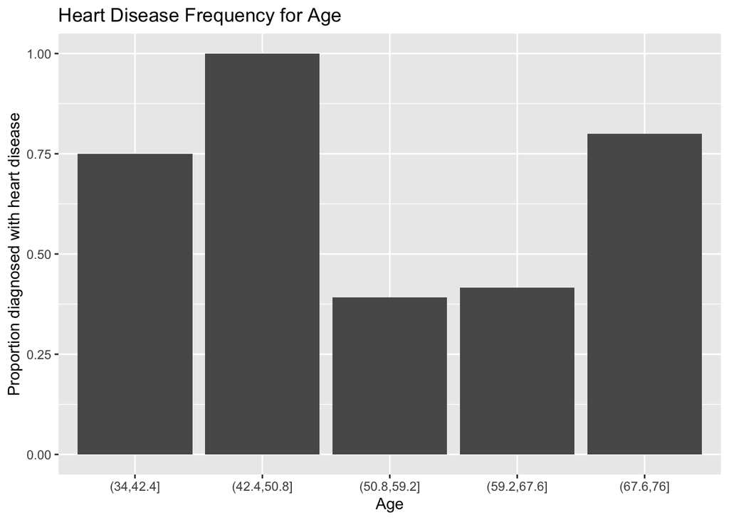

```r
# Time between creating an account to booking
age_cut_heart <- heart %>%
  mutate(age_cut = cut(age, 5)) %>%
  group_by(age_cut)

age_cut_heart %>%
  summarise(
    count = n(),
    freq = sum(ifelse(target == 1, 1, 0)),
    prop = freq/count
  ) %>%
  ggplot(aes(x = age_cut, y = prop)) +
  geom_histogram(stat = "identity") +
  labs(title = "Heart Disease Frequency for Age", y = "Proportion diagnosed with heart disease", x = "Age")
```

#### Sex

From bar chart, we see a larger proportion of observations in female diagnosed with heart disease (17/23). While the proportion of presence in heart disease in male is much lower.

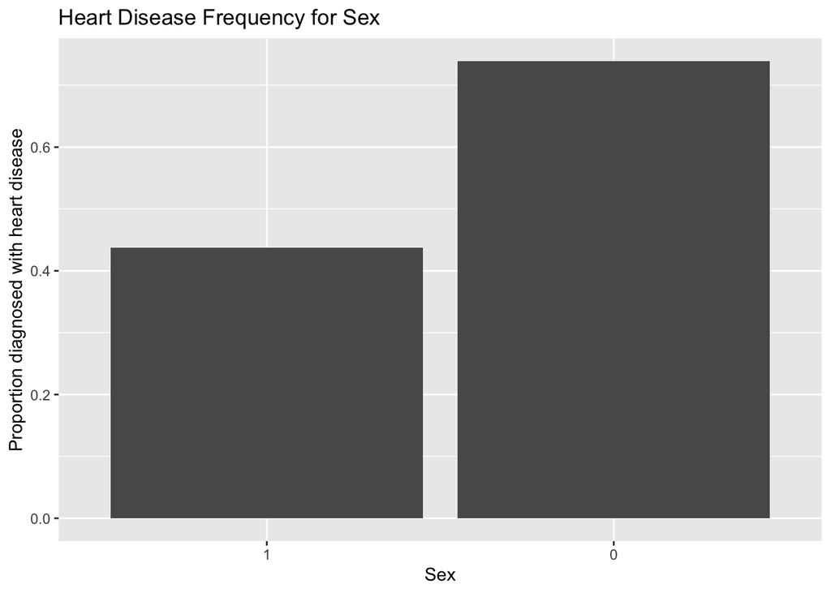

```r
heart %>%
  group_by(sex) %>%
  summarise(
    count = n(),
    freq = sum(ifelse(target == 1, 1, 0)),
    prop = freq/count
  ) %>%
  ggplot(aes(x = sex, y = prop)) +
  geom_histogram(stat = "identity") +
  labs(title = "Heart Disease Frequency for Sex", y = "Proportion diagnosed with heart disease", x = "Sex")
```

### Patient Health Conditions

#### Chest Pain Types

From the simple bar chart below, we can see that there is a seemingly significant decrease in porportion of diagnosed cases for patients that does not show ANY syndrome of chest pain. Thus, we hypothesize that the presence and types of chest pain is probably important in predicting the presence of heart disease.

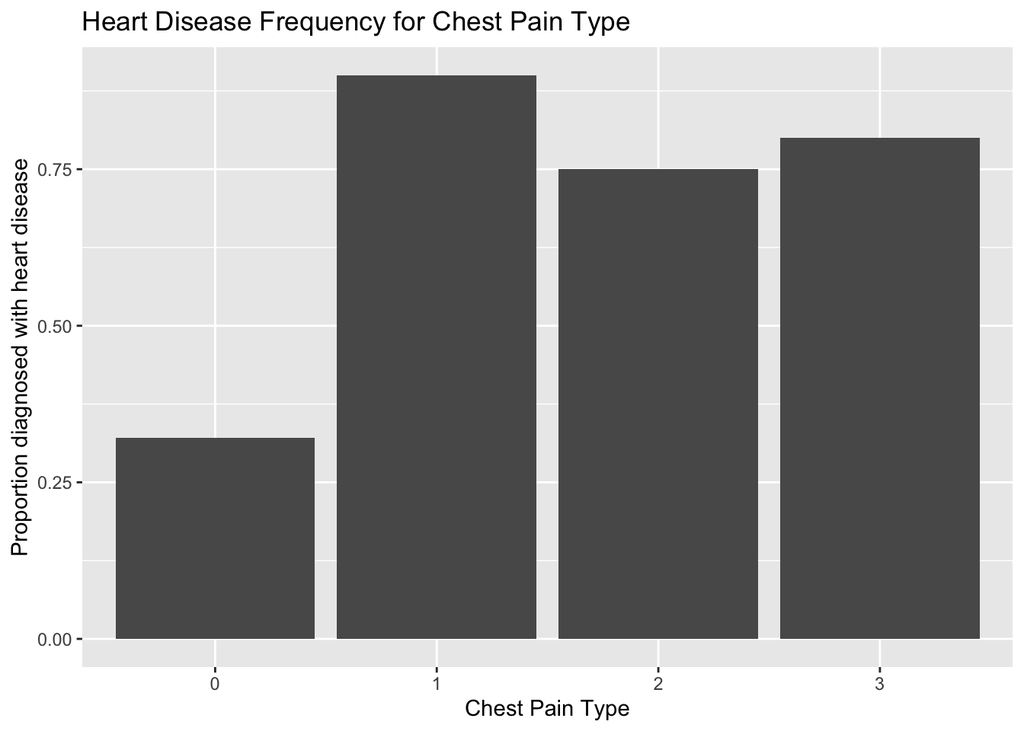

```r
# View proportion of age after replacing outliers with median age value.
heart %>%
  select(cp, target) %>%
  group_by(cp) %>%
  summarise(
    count = n(),
    prop = sum(ifelse(target == 1, 1, 0))/count
  ) %>%
  ggplot(aes(x = cp, y = prop)) +
  geom_bar(stat = "identity") +
  labs(title = "Heart Disease Frequency for Chest Pain Type", y = "Proportion diagnosed with heart disease", x = "Chest Pain Type")
```

#### Maximum Heart Rate

From the boxplot, a higher maximum heart rate seems to correlate with the presence of heart disease.

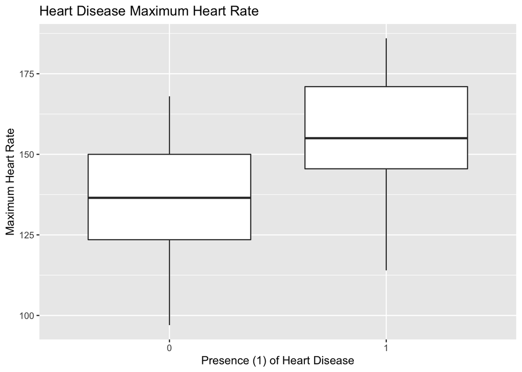

```r
heart %>%
  ggplot(aes(x = target, y = thalach)) +
  geom_boxplot() +
  labs(title = "Heart Disease Maximum Heart Rate", y = "Maximum Heart Rate", x = "Presence (1) of Heart Disease")
```

#### ST depression induced by exercise

From the boxplot, the absence of ST depression seems to correlate with the presence of heart disease. This variable might indicates a malfunction of heart manifested in exercising tests.

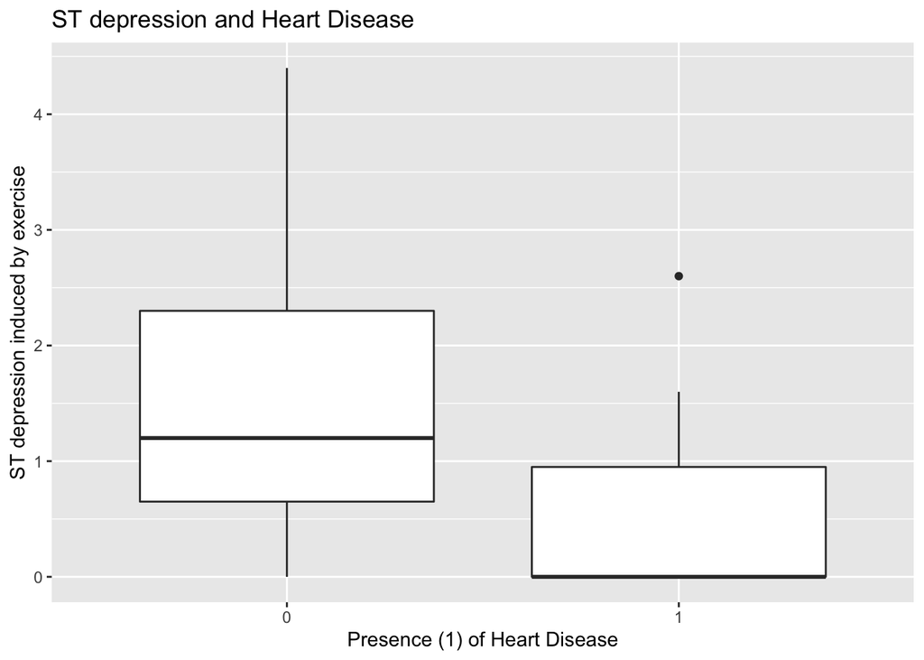

```r
heart %>%
  ggplot(aes(x = target, y = oldpeak)) +
  geom_boxplot() +
  labs(title = "ST depression and Heart Disease", y = "ST depression induced by exercise", x = "Presence (1) of Heart Disease")
```

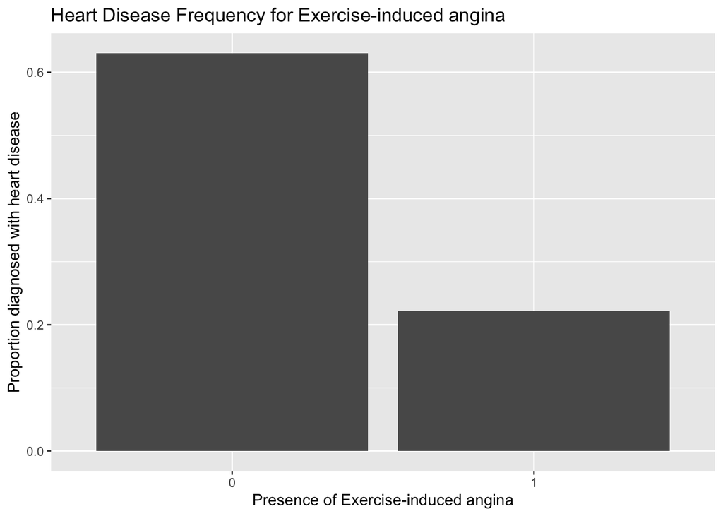

```r
heart %>%
  group_by(fbs) %>%
  summarise(
    count = n(),
    freq = sum(ifelse(target == 1, 1, 0)),
    prop = freq/count
  ) %>%
  ggplot(aes(x = fbs, y = prop)) +
  geom_histogram(stat = "identity") +
  labs(title = "Heart Disease Frequency for Exercise-induced angina", y = "Proportion diagnosed with heart disease", x = "Presence of Exercise-induced angina")
```